# (Prosper Loan Insights and Visualization)

## by (Abdulellah Al-hudaithy)

## Investigation Overview

> In the investigation, I have look at the characteristics of the loans that could be used in proving the relationship between the loan amount and the interest rate (BorrowerRate) after July 2009. The main focus was on the original loan amount, borrower's Prosper rating, loan term, Stated Monthly Income, and MonthlyLoanPayment.

## Dataset Overview

> The Prosper Loan data is about loans since 2005 it's contains apporixametly 114,000 loans and 81 attributes. I have selected the data after July 2009 since the original data have a lot of missing values. It contains about 85,000 loans and I have choice 16 varibales such as Term, BorrowerAPR, BorrowerRate, LoanOriginalAmount, and MonthlyLoanPayment, etc.

## What is the distribution of Loan Amount

> We can notice the distribution of Loan Original Amount looks multimodal and also we can notice that 75% of the loans are almost less than 17K, and since the loans are after the global financial crisis 2008, we could say a lot of people are afraid to take a large number of loans.

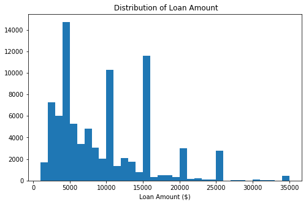

```python
bins = np.arange(1000, new_df['LoanOriginalAmount'].max()+500, 1000)
plt.figure(figsize = [8,5])
plt.hist(data = new_df, x = 'LoanOriginalAmount', bins = bins);
plt.xlabel('Loan Amount ($)');
plt.title(' Distribution of Loan Amount');
```

## What is the distribution of Interest Rate

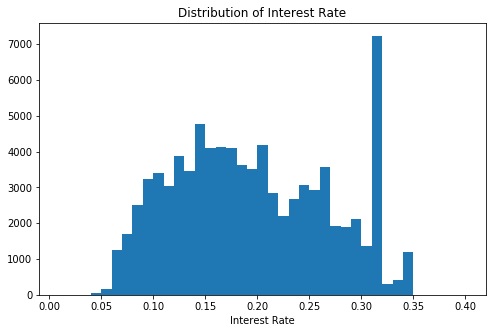

```python
bins =  np.arange(0.01, new_df['BorrowerRate'].max()+0.05, 0.01 )
plt.figure(figsize = [8,5]);
plt.hist(data = new_df, x = 'BorrowerRate', bins = bins);
plt.xlabel('Interest Rate');
plt.title('Distribution of Interest Rate');
```

## What is the relationship between the Loan Original Amount and the Interest Rate

> We can notice there is a reverse relationship, so when the Loan Original Amount increase the interest rate will decrease and quite the opposite.

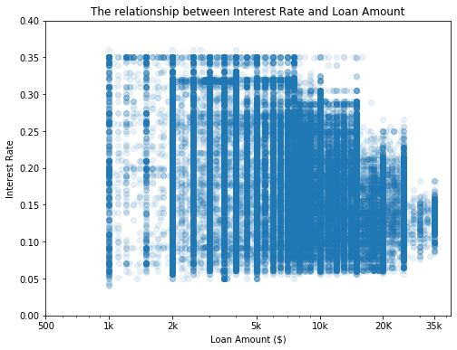

```python
plt.figure(figsize = [8, 6])
plt.scatter(data = new_df, x = 'LoanOriginalAmount', y = 'BorrowerRate' , alpha = 1/10);
plt.ylim([0, 0.4])
plt.xscale('log')
plt.xticks([500, 1e3, 2e3, 5e3, 1e4, 2e4, 3.5e4], [500, '1k', '2k', '5k', '10k', '20K', '35k']);
plt.xlabel('Loan Amount ($)');
plt.ylabel('Interest Rate');
plt.title('The relationship between Interest Rate and Loan Amount');
```

## What is the relationship between BorrowerAPR with Loan Original Amount

> Its looks very similar to the Loan Original Amount and interest rate relationship which is inverse relationship

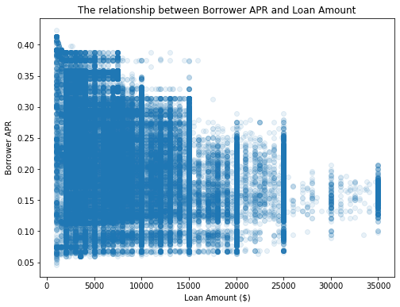

```python
plt.figure(figsize = [8, 6])
sb.regplot(data = new_df, x = 'LoanOriginalAmount', y = 'BorrowerAPR', fit_reg = False, scatter_kws = {'alpha' : 1/10});
plt.xlabel('Loan Amount ($)')
plt.ylabel('Borrower APR')
plt.title('The relationship between Borrower APR and Loan Amount');
```

## How does the Term affect the relationship between the Interest rate and loan original amount?

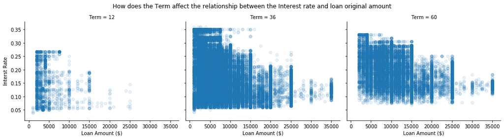

```python
g = sb.FacetGrid(data = new_df, aspect=1.2, height=4, col = 'Term', col_wrap = 3)
g.map(sb.regplot, 'LoanOriginalAmount', 'BorrowerRate', x_jitter=0.04, fit_reg = False, scatter_kws={'alpha':1/10})
g.set_xlabels('Loan Amount ($)')
g.set_ylabels('Interst Rate')
plt.suptitle('How does the Term affect the relationship between the Interest rate and loan original amount');
plt.subplots_adjust(top=0.85)
```